# Eksplorasi data

Weksi Budiaji

2025-09-10

## Styles of Data Analysis

Ketika seorang peneliti memperoleh himpunan data baru untuk dianalisis, pertanyaan mendasar yang muncul adalah bagaimana memulai analisis tersebut. Langkah awal yang penting adalah melakukan eksplorasi data untuk menemukan adanya kesalahan, keanehan, ataupun petunjuk awal mengenai pola yang mungkin terkandung dalam data. Pada tahap ini, penting untuk mempertimbangkan campuran yang seimbang antara analisis eksploratori (Exploratory Data Analysis, EDA) dan analisis formal, serta memperhatikan pula bagaimana penelitian sebelumnya menganalisis data serupa.

Visualisasi data memiliki peran sentral dalam analisis. Ringkasan numerik seperti rata-rata memang bermanfaat, tetapi tanpa grafik, pola penting bisa terlewat. Perangkat lunak statistik modern menghubungkan analisis data dengan grafik, memanfaatkan kemampuan komputasi untuk menyajikan angka sekaligus grafik, sementara mata manusia berperan mendeteksi pola. Model statistik juga sangat penting, karena analisis formal yang bermakna hanya dapat dilakukan jika ada asumsi model yang jelas. Namun, asumsi yang lebih kuat meningkatkan risiko kesalahan apabila asumsi tersebut tidak benar. Oleh karena itu, penggunaan grafik untuk memeriksa validitas asumsi menjadi langkah penting.

Analisis eksploratori yang berlebihan dapat menjebak peneliti pada *data snooping*, yaitu kondisi ketika model analisis terlalu dipengaruhi oleh variasi acak dalam sampel. Data bisa “dipaksa berbicara” sehingga menghasilkan kesimpulan keliru. Dengan demikian, perlu kehati-hatian dalam membiarkan data memengaruhi pemilihan model formal yang akan digunakan.

## Pandangan terhadap Data

Exploratory Data Analysis (EDA) adalah kumpulan teknik eksplorasi data yang memungkinkan data “berbicara sendiri” sebelum atau bersamaan dengan analisis formal. Istilah ini diperkenalkan oleh John W. Tukey, yang menekankan pentingnya grafik dalam pemeriksaan data. EDA bermanfaat karena mampu:

1. Memberikan ide atau pemahaman baru yang sebelumnya tidak terpikirkan.
2. Menantang pemahaman teoretis awal yang mendasari pengumpulan data.
3. Membantu memeriksa asumsi sebelum analisis formal dilakukan.
4. Mengungkap informasi tambahan yang mungkin tidak terkait langsung dengan pertanyaan penelitian utama.

Beberapa bentuk visualisasi EDA yang umum meliputi histogram, diagram batang-daun (*stem-and-leaf*), boxplot, scatterplot, kurva *lowess smoother*, dan grafik bergaya *trellis* (tersedia pada paket `lattice` di R).

### Histogram dan Plot Kepadatan

Histogram adalah alat dasar dalam EDA untuk menunjukkan distribusi frekuensi data. Luas setiap batang histogram proporsional dengan jumlah observasi yang berada dalam rentang nilai tertentu. Histogram berbentuk menyerupai gundukan dapat mengindikasikan bahwa data mengikuti distribusi normal. Namun, bentuk histogram sangat dipengaruhi oleh jumlah sampel dan titik pemotongan (*breakpoints*) yang dipilih, sehingga interpretasi perlu hati-hati.

Sebagai contoh, kita akan menggunakan data `possum` dari paket **DAAG** yang berisi 9 pengukuran morfometrik pada 104 possum gunung. Dari data ini kita ambil subset berisi 43 possum betina (fossum).

```r
# Memanggil paket DAAG
library(DAAG)
# Membuat subset data khusus possum betina
fossum <- subset(possum, sex == "f")

# Menampilkan struktur data
str(fossum)
```

```
## 'data.frame':    43 obs. of  14 variables:
##  $ case    : num  2 3 4 5 6 8 9 10 11 12 ...
##  $ site    : num  1 1 1 1 1 1 1 1 1 1 ...
##  $ Pop     : Factor w/ 2 levels "Vic","other": 1 1 1 1 1 1 1 1 1 1 ...
##  $ sex     : Factor w/ 2 levels "f","m": 1 1 1 1 1 1 1 1 1 1 ...
##  $ age     : num  6 6 6 2 1 6 9 6 9 5 ...
##  $ hdlngth : num  92.5 94 93.2 91.5 93.1 94.8 93.4 91.8 93.3 94.9 ...
##  $ skullw  : num  57.6 60 57.1 56.3 54.8 57.6 56.3 58 57.2 55.6 ...
##  $ totlngth: num  91.5 95.5 92 85.5 90.5 91 91.5 89.5 89.5 92 ...
##  $ taill   : num  36.5 39 38 36 35.5 37 37 37.5 39 35.5 ...
##  $ footlgth: num  72.5 75.4 76.1 71 73.2 72.7 72.4 70.9 77.2 71.7 ...
##  $ earconch: num  51.2 51.9 52.2 53.2 53.6 53.9 52.9 53.4 51.3 51 ...
##  $ eye     : num  16 15.5 15.2 15.1 14.2 14.5 15.5 14.4 14.9 15.3 ...
##  $ chest   : num  28.5 30 28 28.5 30 29 28 27.5 31 28 ...
##  $ belly   : num  33 34 34 33 32 34 33 32 34 33 ...
```

Selanjutnya, kita buat histogram panjang tubuh total (*totlngth*) possum betina dengan dua pilihan titik pemotongan (*breaks*):

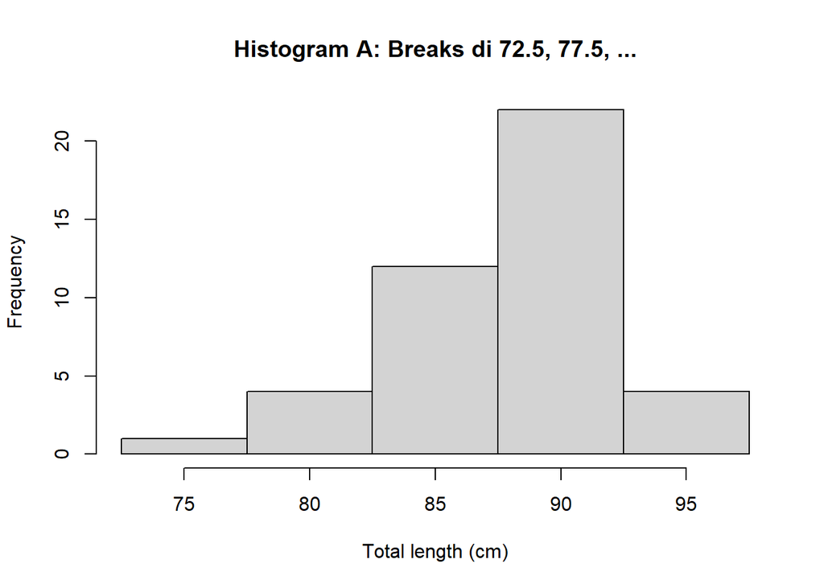

```r
# Histogram dengan break mulai dari 72.5
hist(fossum$totlngth,
     breaks = 72.5 + (0:5) * 5,
     ylim = c(0, 22),
     xlab = "Total length (cm)",
     main = "Histogram A: Breaks di 72.5, 77.5, ...")
```

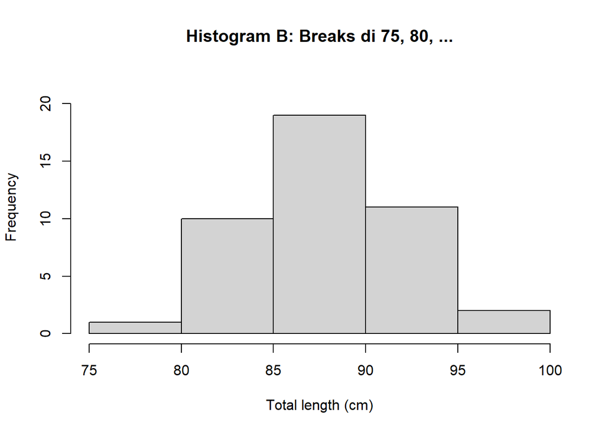

```r
# Histogram dengan break mulai dari 75
hist(fossum$totlngth,
     breaks = 75 + (0:5) * 5,
     ylim = c(0, 22),
     xlab = "Total length (cm)",
     main = "Histogram B: Breaks di 75, 80, ...")
```

Meskipun hanya berbeda pada titik pemotongan, histogram pertama tampak menunjukkan distribusi tidak simetris (skew ke kiri), sementara histogram kedua terlihat lebih simetris. Hal ini menegaskan bahwa interpretasi bentuk distribusi harus dilakukan hati-hati.

Selain histogram, kita dapat menggunakan estimasi kepadatan (*density plot*) yang memberikan gambaran lebih halus mengenai distribusi:

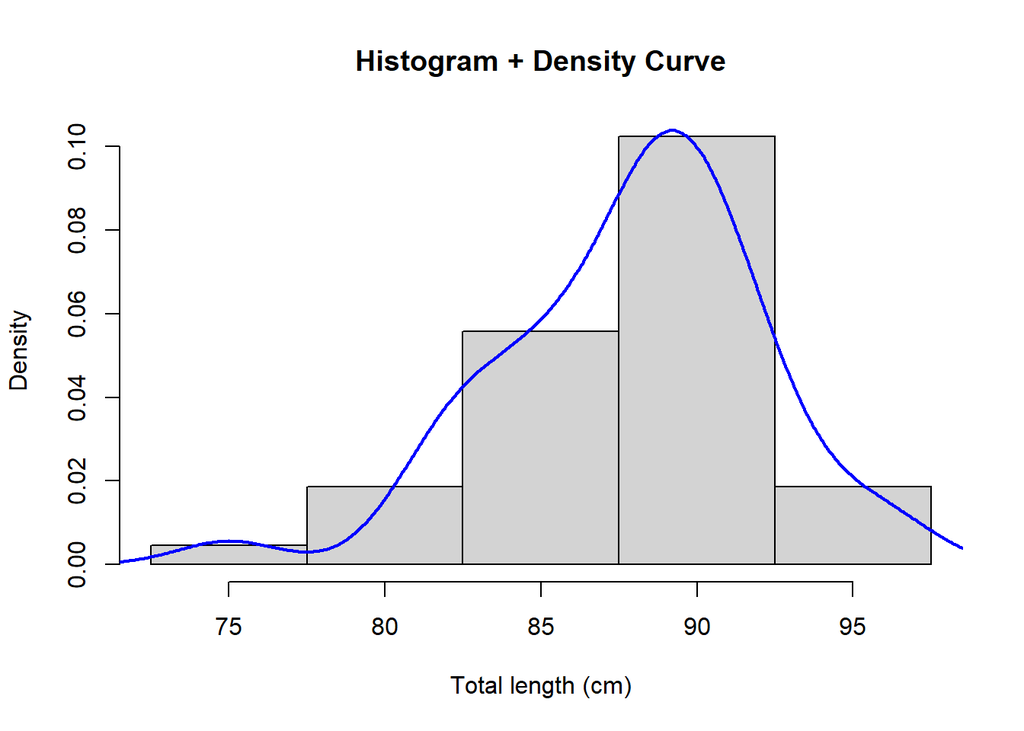

```r
# Estimasi kepadatan
dens <- density(fossum$totlngth)

# Histogram + kurva kepadatan
hist(fossum$totlngth,
     breaks = 72.5 + (0:5) * 5,
     probability = TRUE,
     xlab = "Total length (cm)",
     main = "Histogram + Density Curve")

# Tambahkan garis kepadatan
lines(dens, col = "blue", lwd = 2)
```

Kurva kepadatan dapat membantu mendeteksi bentuk distribusi, seperti kemiringan (skewness) atau keberadaan beberapa puncak (multimodalitas), yang mungkin tidak terlihat jelas pada histogram.

### Stem-and-Leaf Display

Diagram batang-daun (*stem-and-leaf*) adalah alternatif yang lebih detail dibanding histogram untuk menampilkan distribusi satu kolom data numerik. Keunggulannya, plot ini tetap menunjukkan nilai asli data, bukan sekadar ringkasan frekuensi.

Sebagai contoh, kita gunakan data `ais` (Australian Institute of Sport) dari paket **DAAG**, khusus untuk tinggi badan (*ht*) dari atlet cabang olahraga *Rowing*:

```r
# Stem-and-leaf plot tinggi badan rowers
stem(ais$ht[ais$sport == "Row"])
```

```
##
##   The decimal point is 1 digit(s) to the right of the |
##
##   15 | 6
##   16 |
##   16 | 5
##   17 | 4
##   17 | 5678899
##   18 | 00000011223
##   18 | 55666668899
##   19 | 123
##   19 | 58
```

Interpretasi:

- Angka di kiri `|` (misal 15, 16, 17, …) disebut **stem**: bagian puluhan cm.
- Angka di kanan `|` (misal 6, 5, 4567, …) disebut **leaf**: bagian satuan cm.
- Contoh: baris `18 | 2` mewakili data **182 cm**.

Dari 37 data rower, median (nilai ke-19) ada pada **182 cm**. Kuartil pertama (Q1) sekitar **179 cm**, sedangkan kuartil ketiga (Q3) sekitar **186 cm**. Dengan demikian, stem-and-leaf tidak hanya menampilkan distribusi, tapi juga memudahkan perkiraan median dan kuartil.

### Lattice Style Density Plots

Paket **lattice** di R menyediakan grafik kepadatan (*density plot*) yang lebih fleksibel, misalnya untuk membandingkan distribusi antar kelompok. Contoh berikut menampilkan distribusi ukuran *earconch* possum, dibedakan berdasarkan jenis kelamin (`sex`) dan populasi (`Pop`):

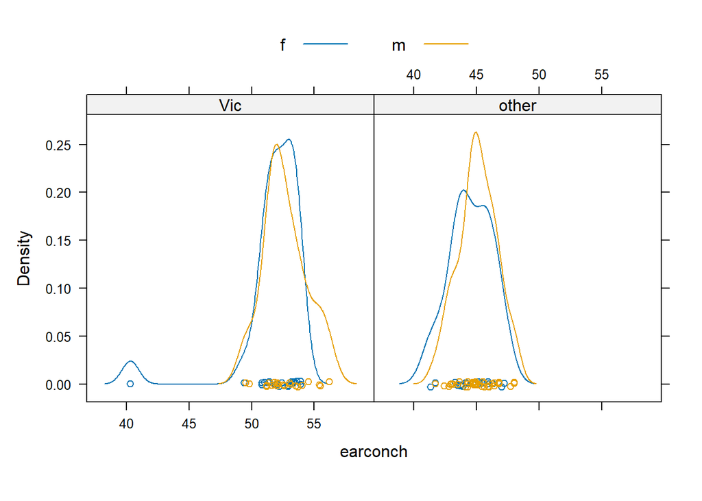

```r
library(lattice)

# Density plot untuk earconch berdasarkan sex dan Pop
densityplot(~ earconch | Pop, groups = sex, data = possum,
            auto.key = list(columns = 2), aspect = 1)
```

Plot ini memudahkan kita melihat perbedaan distribusi antar kelompok (misalnya perbedaan ukuran *earconch* jantan vs betina pada populasi tertentu).

### Boxplots

Boxplot adalah ringkasan grafis distribusi data yang memungkinkan kita dengan cepat mengenali pusat data, sebaran, serta kemungkinan adanya pencilan (*outlier*).

Contoh berikut membuat boxplot untuk panjang tubuh total (*totlngth*) possum betina (`fossum`):

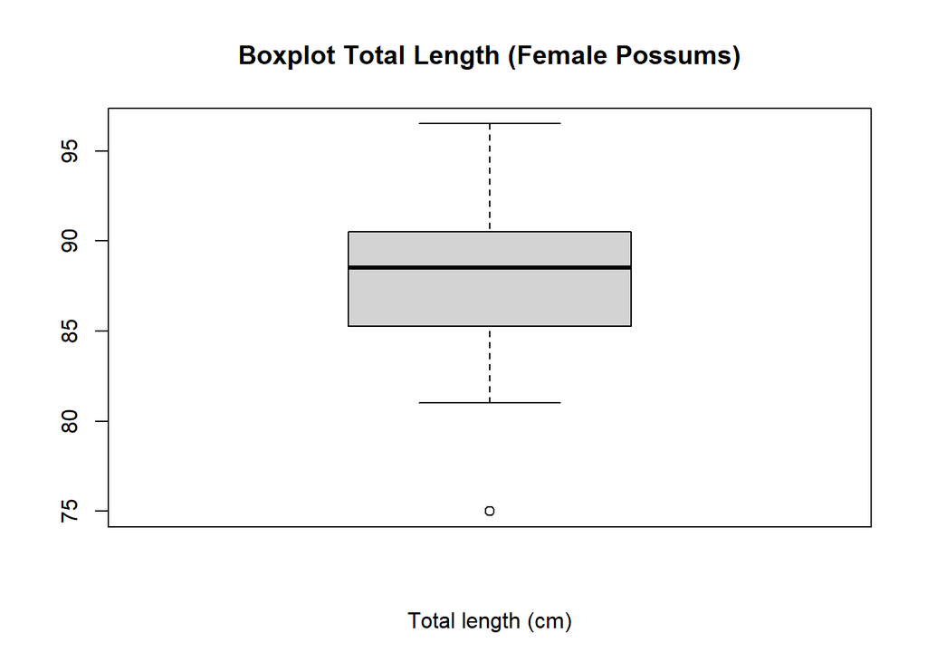

```r
# Boxplot dengan base R
boxplot(fossum$totlngth, horiz = TRUE,
        main = "Boxplot Total Length (Female Possums)",
        xlab = "Total length (cm)")
```

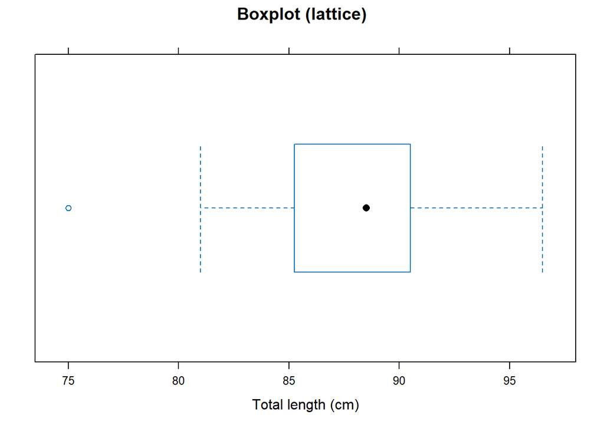

```r
# Boxplot dengan lattice (alternatif)
bwplot(~ totlngth, data = fossum,
       main = "Boxplot (lattice)",
       xlab = "Total length (cm)")
```

Interpretasi boxplot:

- Kotak (*box*) menunjukkan rentang kuartil pertama (Q1) sampai kuartil ketiga (Q3).
- Garis di dalam kotak adalah median (Q2).
- “Whiskers” memperluas jangkauan data hingga batas tertentu.
- Titik di luar whiskers dianggap **outlier potensial**.

Dalam contoh data possum betina, terlihat ada satu nilai yang terletak di luar whiskers, sehingga ditandai sebagai *outlier*. Perlu diingat, dalam distribusi normal pun, sekitar 1% data secara acak akan muncul sebagai outlier menurut kriteria default boxplot.

### Pola pada Deret Waktu Univariat

Data deret waktu (time series) sering kali menyimpan pola yang tidak langsung terlihat dari ringkasan numerik. Salah satu contoh klasik adalah data jumlah kematian akibat campak (*measles*) di London selama periode 1629–1939, yang tersedia dalam paket **DAAG**. Data ini juga dibandingkan dengan data populasi London (*londonpop*).

### Panel A: Skala Logaritmik

Panel pertama menggunakan skala logaritmik pada sumbu vertikal. Tujuannya adalah untuk menangkap pola jangka panjang, karena jumlah kematian akibat campak sangat bervariasi sepanjang waktu. Dengan skala log, baik jumlah kematian maupun ukuran populasi dapat ditampilkan bersama-sama.

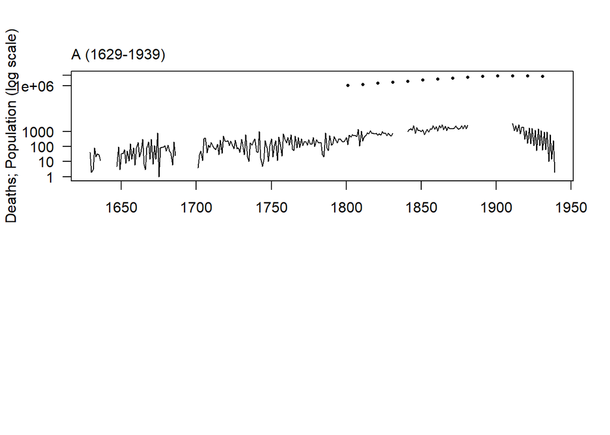

```r
# Data populasi London dalam ribuan
londonpop <- ts(c(1088,1258,1504,1778,2073,2491,2921,
                  3336,3881,4266,4563,4541,4498,4408),
                start = 1801, end = 1931, deltat = 10)

# Panel A: Plot time series dengan skala log
par(fig = c(0, 1, .38, 1))  # 38% - 100% area plot
plot(log10(measles),
     xlab = "",
     ylim = log10(c(1, 5000*1000)),
     ylab = "Deaths; Population (log scale)",
     yaxt = "n")

# Tambahkan sumbu dengan ticks log
ytiks <- c(1, 10, 100, 1000, 1000000, 5000000)
axis(2, at = log10(ytiks), labels = paste(ytiks), las = 2)

# Tambahkan data populasi London (dalam individu, bukan ribuan)
points(log10(londonpop*1000), pch = 16, cex = 0.5)

# Judul panel
mtext(side = 3, line = 0.5, "A (1629-1939)", adj = 0)
```

Interpretasi: Panel ini memperlihatkan tren jangka panjang, misalnya hubungan antara pertumbuhan populasi London dan jumlah kematian akibat campak. Namun, detail fluktuasi tahunan tidak tampak jelas karena data sangat dipadatkan.

### Panel B: Skala Linear dengan Subset Waktu

Panel kedua fokus pada periode 1840–1882, menggunakan skala linear agar pola tahunan lebih jelas terlihat.

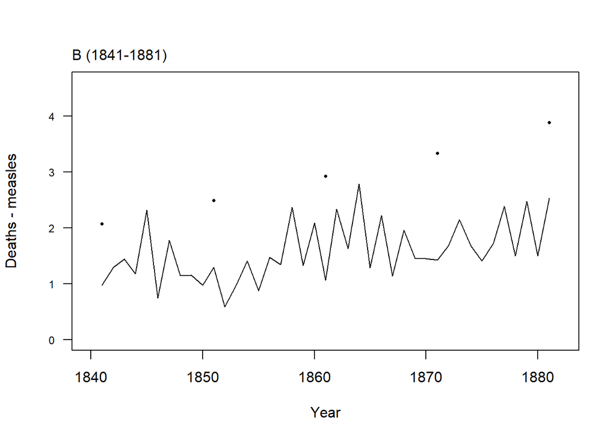

```r
# Panel B: Subset data 1840–1882
plot(window(measles, start = 1840, end = 1882),
     xlab = "Year",
     ylim = c(0, 4600),
     yaxt = "n",
     ylab = "Deaths - measles")

# Tambahkan populasi London (skala berbeda)
points(londonpop, pch = 16, cex = 0.5)

# Tambahkan sumbu y dengan ribuan
axis(2, at = (0:4)*1000, labels = paste(0:4), las = 2, cex.axis = 0.75)

# Judul panel
mtext(side = 3, line = 0.5, "B (1841-1881)", adj = 0)
```

Interpretasi:

- Panel B memperlihatkan **pola siklik** (*sawtooth pattern*), yaitu tahun dengan banyak kematian biasanya diikuti tahun dengan sedikit kematian.
- Fluktuasi ini mencerminkan dinamika penyebaran penyakit menular: setelah terjadi epidemi besar (banyak orang terinfeksi), populasi yang rentan berkurang, sehingga tahun berikutnya jumlah kasus menurun.
- Setelah beberapa tahun, jumlah individu rentan bertambah lagi (misalnya karena kelahiran baru), memicu epidemi berikutnya.

**Kesimpulan:**

- Skala logaritmik (Panel A) berguna untuk melihat tren jangka panjang.
- Skala linear dengan subset (Panel B) lebih informatif untuk melihat pola tahunan dan siklus penyakit.
- Untuk seluruh periode panjang (1629–1939), akan diperlukan beberapa panel agar pola jangka pendek tetap terlihat jelas.

### Pola pada Data Bivariat

Salah satu tema utama dalam sains adalah menemukan **pola dan hubungan** antar variabel. Dalam statistik, hal ini sering dianalisis melalui **scatterplot**, yaitu grafik sebar yang memperlihatkan hubungan antara dua variabel. Scatterplot memungkinkan kita melihat apakah ada pola linear, non-linear, adanya pencilan, maupun korelasi antara dua variabel.

Contoh: Data Eksperimen Rasa Manis Susu

Sebagai ilustrasi, digunakan data `milk` dari paket **DAAG**. Data ini berasal dari eksperimen rasa manis oleh 17 panelis, yang masing-masing diminta menilai rasa manis dari dua sampel susu:

- Satu sampel dengan **empat unit zat aditif** (`four`).
- Satu sampel dengan **satu unit zat aditif** (`one`).

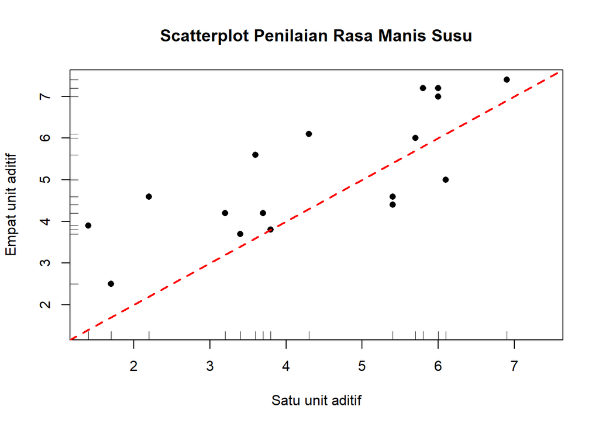

```r
# Menentukan rentang nilai
xyrange <- range(milk)

# Scatterplot rasa manis (empat unit vs satu unit aditif)
plot(four ~ one, data = milk,
     xlim = xyrange, ylim = xyrange,
     pch = 16, pty = "s",  # square plotting region
     main = "Scatterplot Penilaian Rasa Manis Susu",
     xlab = "Satu unit aditif",
     ylab = "Empat unit aditif")

# Tambahkan rug plot pada sumbu x dan y
rug(milk$one)             # default: sumbu bawah (x-axis)
rug(milk$four, side = 2)  # rug plot pada sumbu kiri (y-axis)

# Tambahkan garis y = x sebagai acuan
abline(0, 1, col = "red", lwd = 2, lty = 2)
```

Interpretasi:

- **Korelasi positif** terlihat: panelis yang menilai sampel dengan satu unit aditif lebih manis, cenderung juga menilai sampel dengan empat unit aditif lebih manis.
- Garis merah `y = x` membantu membandingkan langsung dua sampel:
- Titik **di atas garis**: panelis menilai sampel empat unit aditif lebih manis.
- Titik **di bawah garis**: panelis menilai sampel satu unit aditif lebih manis.
- Dari hasil, **13 dari 17 panelis** menilai susu dengan **empat unit aditif lebih manis**.

Selain pola umum, scatterplot juga memperlihatkan distribusi nilai pada masing-masing variabel melalui **rug plot** (garis-garis kecil di sepanjang sumbu). Ini membantu mengidentifikasi apakah data menumpuk pada rentang tertentu.

**Kesimpulan:** Scatterplot sangat berguna untuk menganalisis hubungan dua variabel. Penambahan elemen seperti rug plot atau garis referensi (misalnya `y = x`) dapat meningkatkan kemampuan interpretasi, membantu kita melihat tren, perbedaan antar kelompok, maupun pencilan.

### Skala apa yang tepat?

Ketika membuat plot, **pemilihan skala** sangat penting agar pola dalam data bisa terlihat jelas. Pada gambar berikut, data **berat otak (gram)** dipetakan terhadap **berat tubuh (kg)** dari berbagai hewan dengan skala biasa (*linear scale*). Namun, hasilnya hampir tidak informatif: sebagian besar titik data terdesak di sudut bawah grafik, sementara beberapa titik ekstrem mendominasi sumbu.

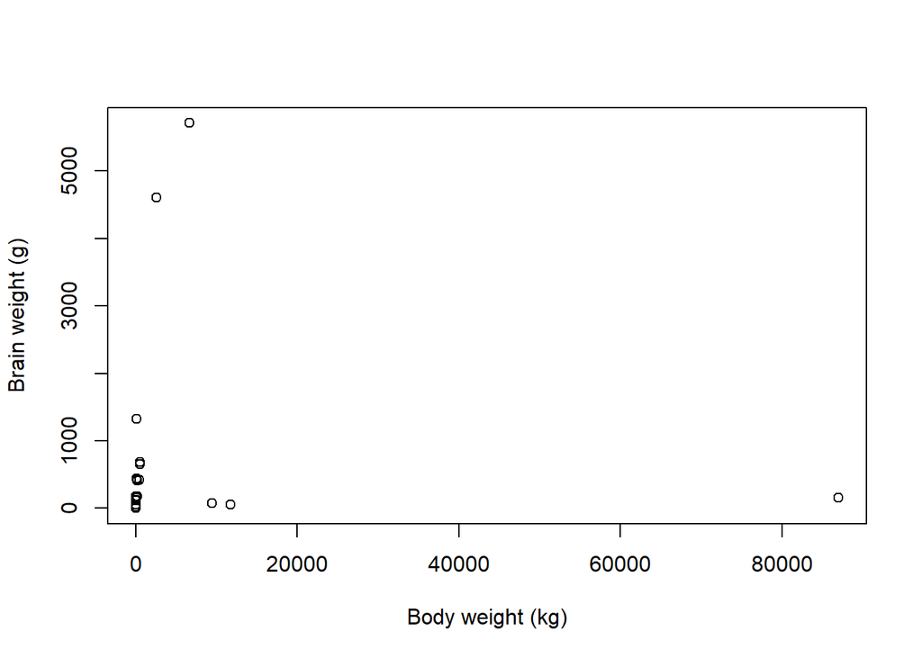

```r
library(MASS)
# Panel A: skala linear
plot(brain ~ body, data = Animals,
     xlab = "Body weight (kg)",
     ylab = "Brain weight (g)")
```

Untuk memperbaikinya, digunakan **transformasi logaritmik** pada kedua variabel:

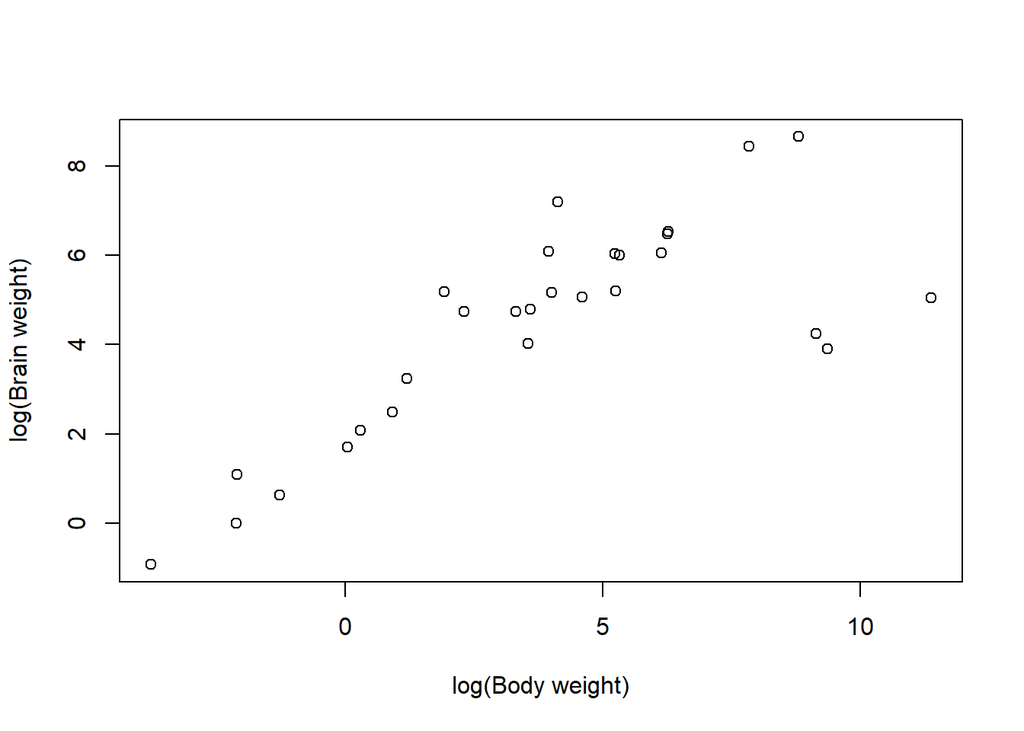

```r
# Panel B: skala logaritmik
plot(log(brain) ~ log(body), data = Animals,
     xlab = "log(Body weight)",
     ylab = "log(Brain weight)")
```

Mengapa Skala Logaritmik?

- Pada **skala linear**, perbedaan kecil di bagian bawah (misalnya 1–10 kg tubuh) hampir tidak terlihat jika dibandingkan dengan perbedaan besar di bagian atas (ribuan kg).
- **Skala log** membuat data yang awalnya terjepit lebih **tersebar merata**, sehingga pola hubungan lebih mudah dianalisis.
- Prinsipnya: pada skala log, penggandaan nilai (×10, ×100, ×1000, …) selalu berjarak sama.

Kapan Logaritmik Cocok?

1. **Pertumbuhan Multiplikatif:** Misalnya sel membelah dengan laju tetap → jumlah sel bertambah secara eksponensial.
2. **Ukuran Biologis:** Pertumbuhan tubuh organisme cenderung proporsional (bertambah dengan persentase tertentu, bukan jumlah absolut).
3. **Distribusi Log-Normal:** Variasi alami ukuran tubuh sering kali mendekati normal **jika di-log-kan**.

Intinya, transformasi log sangat umum dalam biologi, ekonomi, maupun ilmu sosial karena membantu menampilkan hubungan yang sifatnya **proporsional** atau **eksponensial**.

### Tugas

1. Buka data `airquality`
2. Buat histogram untuk variabel `Wind`, sertakan pula density nya
3. Buat boxplot dan steam and leaf
4. Buat scatter plot